# Session 1: Transformations into stationarity

### RMarkdown Introduction

https://rmarkdown.rstudio.com/

https://www.rstudio.com/wp-content/uploads/2015/03/rmarkdown-spanish.pdf

https://www.rstudio.com/wp-content/uploads/2015/02/rmarkdown-cheatsheet.pdf

## Aim: Given three time series (Nottem, GNPSH, Airpassengers), transform them into stationarity.

### 1. Nottem

Average Monthly Temperatures at Nottingham, 1920-1939

Description: A time series object containing average air temperatures at Nottingham Castle in degrees Fahrenheit for 20 years.

```r
#?nottem
nottem # List Nottem observations
```

```
##       Jan  Feb  Mar  Apr  May  Jun  Jul  Aug  Sep  Oct  Nov  Dec
## 1920 40.6 40.8 44.4 46.7 54.1 58.5 57.7 56.4 54.3 50.5 42.9 39.8
## 1921 44.2 39.8 45.1 47.0 54.1 58.7 66.3 59.9 57.0 54.2 39.7 42.8
## 1922 37.5 38.7 39.5 42.1 55.7 57.8 56.8 54.3 54.3 47.1 41.8 41.7
## 1923 41.8 40.1 42.9 45.8 49.2 52.7 64.2 59.6 54.4 49.2 36.3 37.6
## 1924 39.3 37.5 38.3 45.5 53.2 57.7 60.8 58.2 56.4 49.8 44.4 43.6
## 1925 40.0 40.5 40.8 45.1 53.8 59.4 63.5 61.0 53.0 50.0 38.1 36.3
## 1926 39.2 43.4 43.4 48.9 50.6 56.8 62.5 62.0 57.5 46.7 41.6 39.8
## 1927 39.4 38.5 45.3 47.1 51.7 55.0 60.4 60.5 54.7 50.3 42.3 35.2
## 1928 40.8 41.1 42.8 47.3 50.9 56.4 62.2 60.5 55.4 50.2 43.0 37.3
## 1929 34.8 31.3 41.0 43.9 53.1 56.9 62.5 60.3 59.8 49.2 42.9 41.9
## 1930 41.6 37.1 41.2 46.9 51.2 60.4 60.1 61.6 57.0 50.9 43.0 38.8
## 1931 37.1 38.4 38.4 46.5 53.5 58.4 60.6 58.2 53.8 46.6 45.5 40.6
## 1932 42.4 38.4 40.3 44.6 50.9 57.0 62.1 63.5 56.3 47.3 43.6 41.8
## 1933 36.2 39.3 44.5 48.7 54.2 60.8 65.5 64.9 60.1 50.2 42.1 35.8
## 1934 39.4 38.2 40.4 46.9 53.4 59.6 66.5 60.4 59.2 51.2 42.8 45.8
## 1935 40.0 42.6 43.5 47.1 50.0 60.5 64.6 64.0 56.8 48.6 44.2 36.4
## 1936 37.3 35.0 44.0 43.9 52.7 58.6 60.0 61.1 58.1 49.6 41.6 41.3
## 1937 40.8 41.0 38.4 47.4 54.1 58.6 61.4 61.8 56.3 50.9 41.4 37.1
## 1938 42.1 41.2 47.3 46.6 52.4 59.0 59.6 60.4 57.0 50.7 47.8 39.2
## 1939 39.4 40.9 42.4 47.8 52.4 58.0 60.7 61.8 58.2 46.7 46.6 37.8
```

```r
# Some useful properties of a time series object
class(nottem) #Type of object
```

```
## [1] "ts"
```

```r
str(nottem) #Type  plus atributes
```

```
##  Time-Series [1:240] from 1920 to 1940: 40.6 40.8 44.4 46.7 54.1 58.5 57.7 56.4 54.3 50.5 ...
```

```r
length(nottem)         #No. of observations
```

```
## [1] 240
```

```r
(stno=start(nottem))   #Starting point ...
```

```
## [1] 1920    1
```

```r
(enno=end(nottem))     #Ending point ...
```

```
## [1] 1939   12
```

```r
frequency(nottem)      # No. of (months) in a (year)
```

```
## [1] 12
```

```r
(enno[1]-stno[1]+1)
```

```
## [1] 20
```

```r
(enno[1]-stno[1]+1) * frequency(nottem) #No. of observations
```

```
## [1] 240
```

### Is Variance constant?

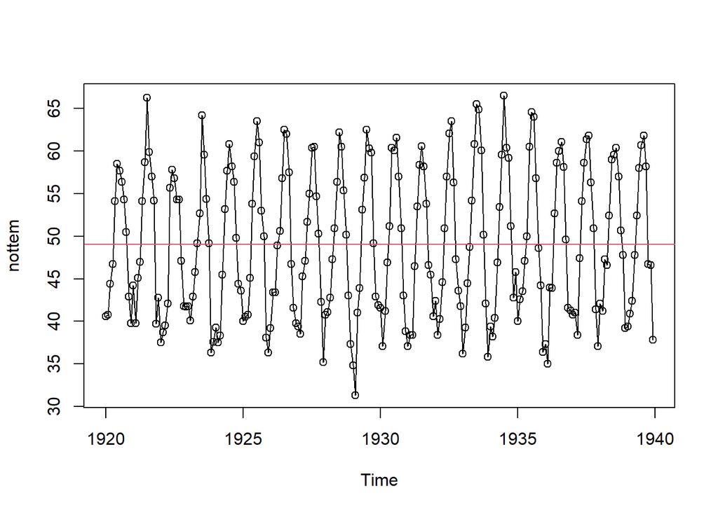

```r
plot(nottem,type="o")
#LA
abline(h=mean(nottem), col=2)
```

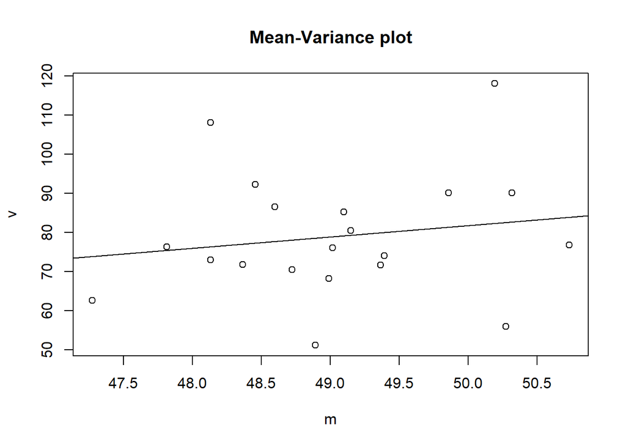

```r
 m=apply(matrix(nottem,ncol=20),2,mean) #lleno matrix 12x20 x columnas y get media por cada a?o
 v=apply(matrix(nottem,ncol=20),2,var)
 plot(v~m,main="Mean-Variance plot")
 abline(lm(v~m))
```

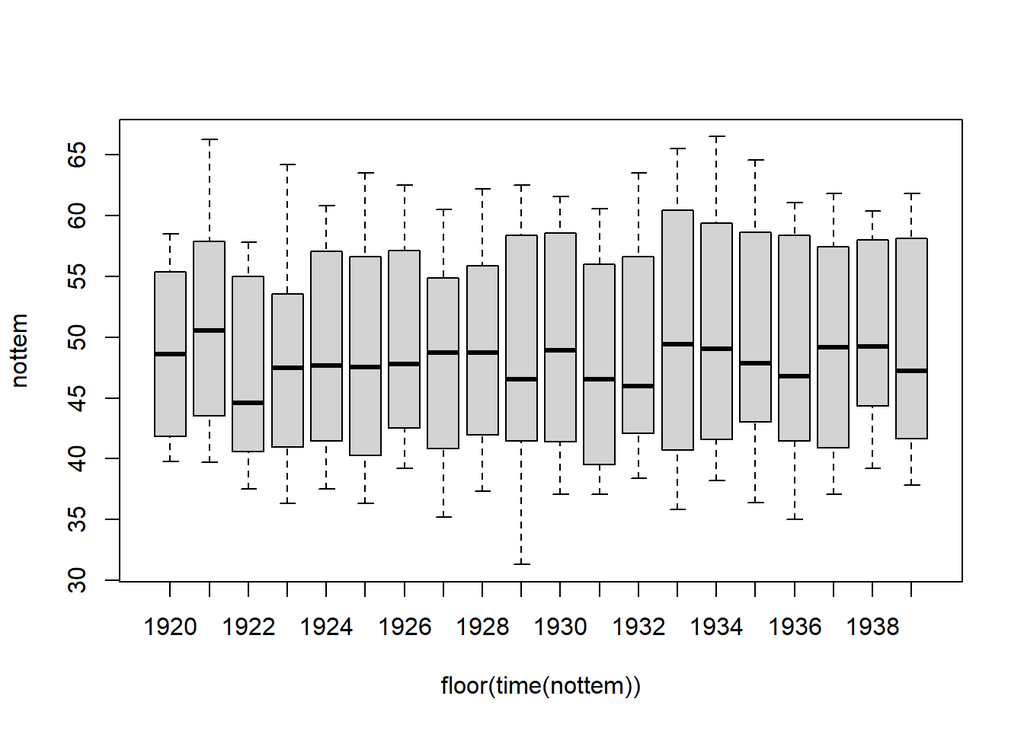

```r
##boxplot per each year
boxplot(nottem~floor(time(nottem)))
```

#### The varianza seemingly constant!

### Is seasonality present?

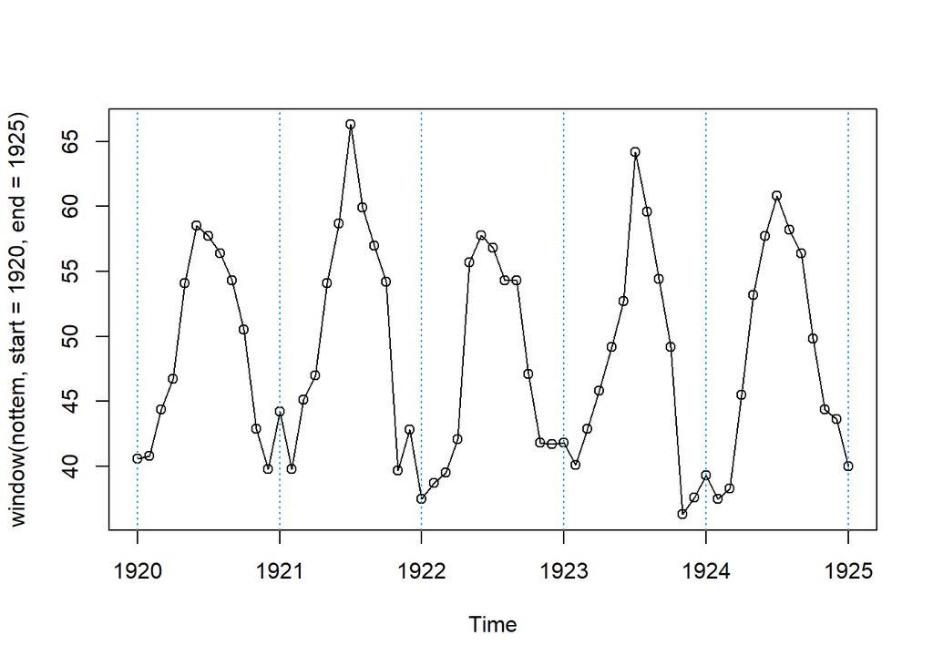

```r
plot(window(nottem,start=1920,end=1925),type="o")   #Zoom
abline(v=1920:1925,col=4,lty=3)
```

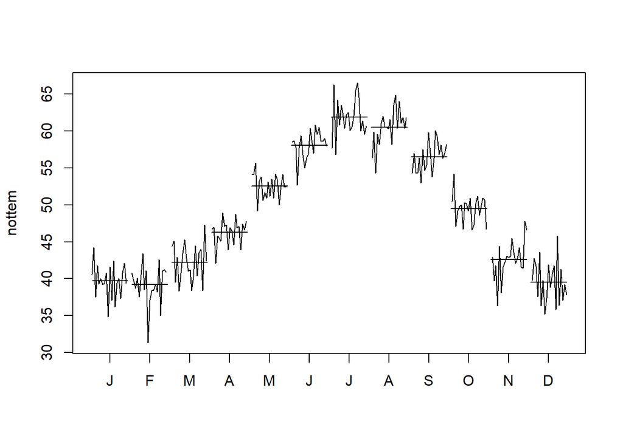

```r
monthplot(nottem)
```

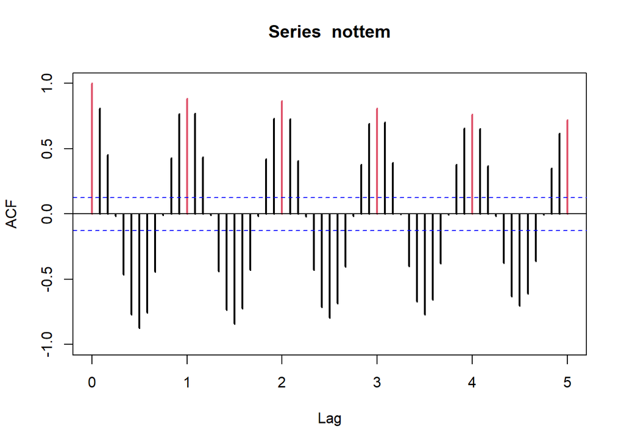

```r
# ACF decreasing slowly => non-stationarity
acf(nottem,ylim=c(-1,1),lag.max=60,col=c(2,rep(1,11)),lwd=2)
```

#### Yes, a pattern repeats itself every s=12 months

```r
##
# Difference of order 12 to remove the seasonal component
d12nottem=diff(nottem,12)
```

### Is the mean constant?

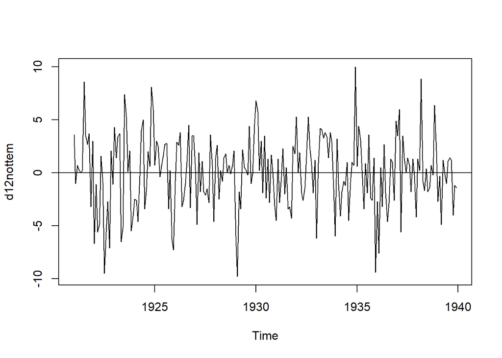

```r
plot(d12nottem)
abline(h=0)
```

```r
#var(d12nottem)
#var(diff(d12nottem))
```

#### Yes, time series seemingly constant with mean around 0

### Is the transformed series already stationary?

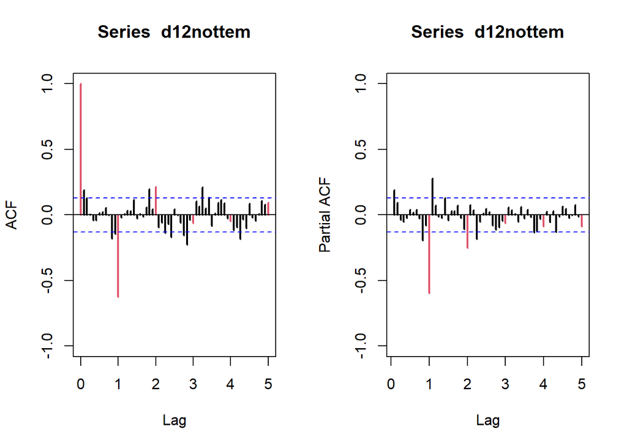

```r
# Constant mean, constant variance, ACF with fast decay => stationarity
par(mfrow=c(1,2))
acf(d12nottem,ylim=c(-1,1),lag.max=60,col=c(2,rep(1,11)),lwd=2)
pacf(d12nottem,ylim=c(-1,1),lag.max=60,col=c(rep(1,11),2),lwd=2)
```

```r
par(mfrow=c(1,1))

#monthplot(d12nottem)
```

### Summary: Series d12Nottem has constant mean and variance.ACF decaying rapidly towards 0. => Stationarity achieved

$$W_t=(1-B^{12})X_t=X_t-X_{t-12}$$

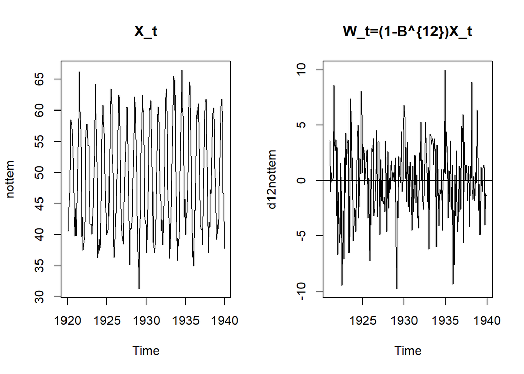

```r
par(mfrow=c(1,2))
plot(nottem,main="X_t")
plot(d12nottem,main="W_t=(1-B^{12})X_t")
abline(h=0)
```

```r
par(mfrow=c(1,1))
```

### 2. GNPSH

Gross National Product USA, Quarterly data (I/1947-I/1991) Seasonally adjusted

Description: Gross national product (GNP) is the market value of all the products and services produced in one year by labor and property supplied by the citizens of a countryhttps://en.wikipedia.org/wiki/Gross_national_product.

```r
# Object ts (time series): starting in 1947 and frequency 4 (quarterly data)
(gnpsh=ts(read.table("gnpsh.dat")[,1],start=1947,freq=4))
```

```
##         Qtr1    Qtr2    Qtr3    Qtr4
## 1947 1056.50 1063.20 1067.10 1080.00
## 1948 1086.80 1106.10 1116.31 1125.50
## 1949 1112.41 1105.89 1114.30 1103.30
## 1950 1148.20 1181.00 1225.30 1260.21
## 1951 1286.60 1320.40 1349.80 1355.99
## 1952 1369.20 1365.90 1378.20 1406.80
## 1953 1431.40 1444.91 1438.20 1426.60
## 1954 1406.80 1401.19 1418.00 1438.79
## 1955 1469.61 1485.70 1505.50 1518.70
## 1956 1515.70 1522.59 1523.70 1540.60
## 1957 1553.30 1552.40 1561.50 1537.30
## 1958 1506.10 1514.20 1550.00 1586.70
## 1959 1606.40 1637.00 1629.50 1643.40
## 1960 1671.61 1666.80 1668.40 1654.10
```

[output cut: 31 more lines]

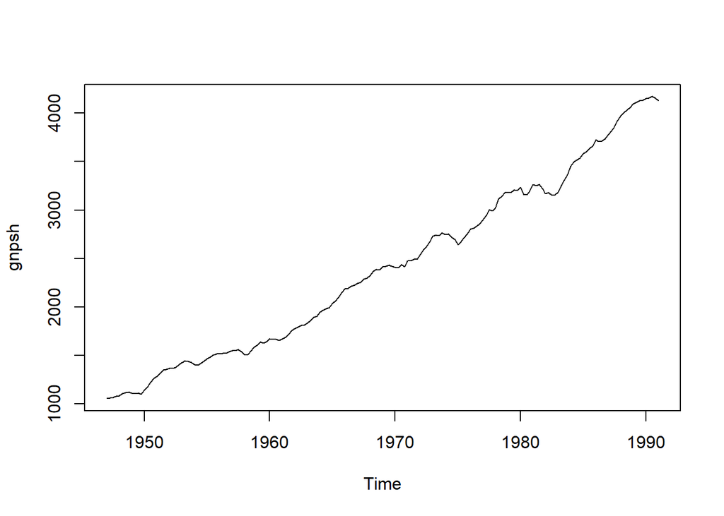

```r
plot(gnpsh)
```

```r
start(gnpsh)        #Starting point ...
```

```
## [1] 1947    1
```

```r
end(gnpsh)          #Ending point ...
```

```
## [1] 1991    1
```

```r
frequency(gnpsh)    # No. of (quarters) in a (year)
```

```
## [1] 4
```

```r
length(gnpsh)       #No. of observations
```

```
## [1] 177
```

```r
#(end(gnpsh)[1]-start(gnpsh)[1]+1)*4 -3
```

### Is Variance constant?

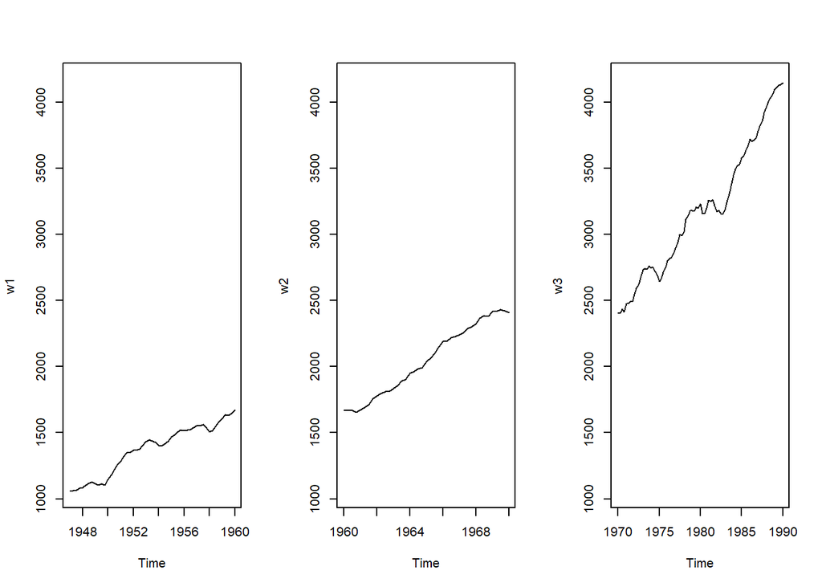

```r
w1 <- window(gnpsh,start=1947,end=1960)
w2 <- window(gnpsh,start=1960,end=1970)
w3 <- window(gnpsh,start=1970,end=1990)

par(mfrow=c(1,3))
plot(w1,ylim=c(min(gnpsh),max(gnpsh)))
plot(w2,ylim=c(min(gnpsh),max(gnpsh)))
plot(w3,ylim=c(min(gnpsh),max(gnpsh)))
```

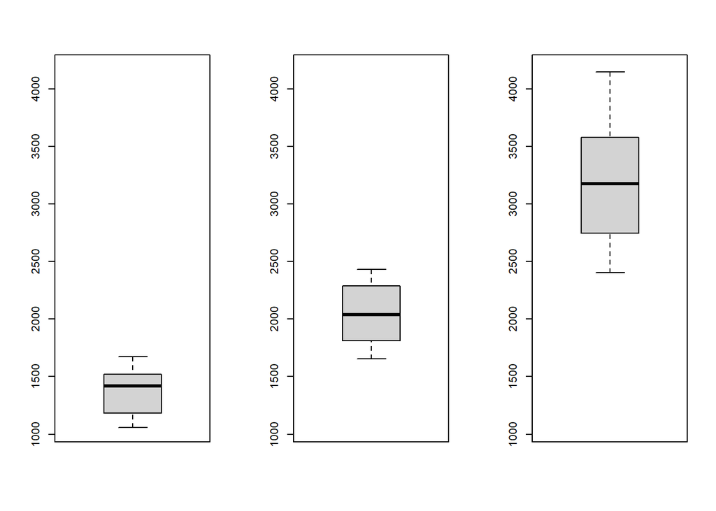

```r
par(mfrow=c(1,3))
boxplot(w1,ylim = c(min(gnpsh),max(gnpsh)))
boxplot(w2,ylim = c(min(gnpsh),max(gnpsh)))
boxplot(w3,ylim = c(min(gnpsh),max(gnpsh)))
```

##### Variance appears to be non-constant: it seems to change with the level of the series

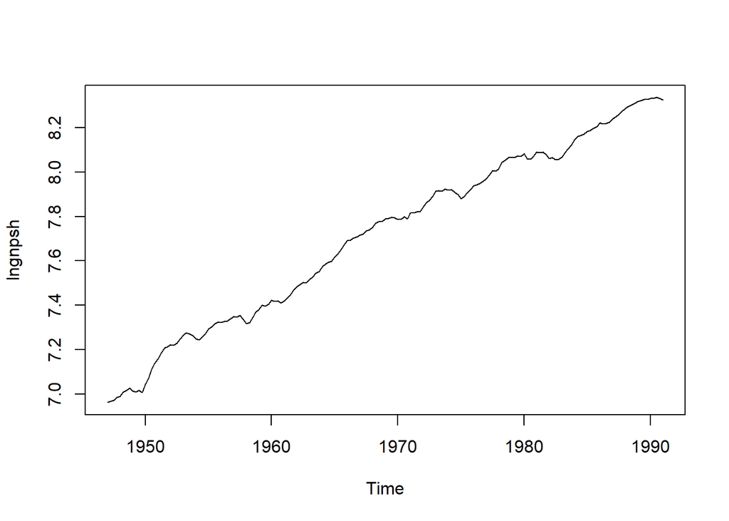

```r
# Logarithm transformation to stabilize the variance
lngnpsh=log(gnpsh)
plot(lngnpsh)
```

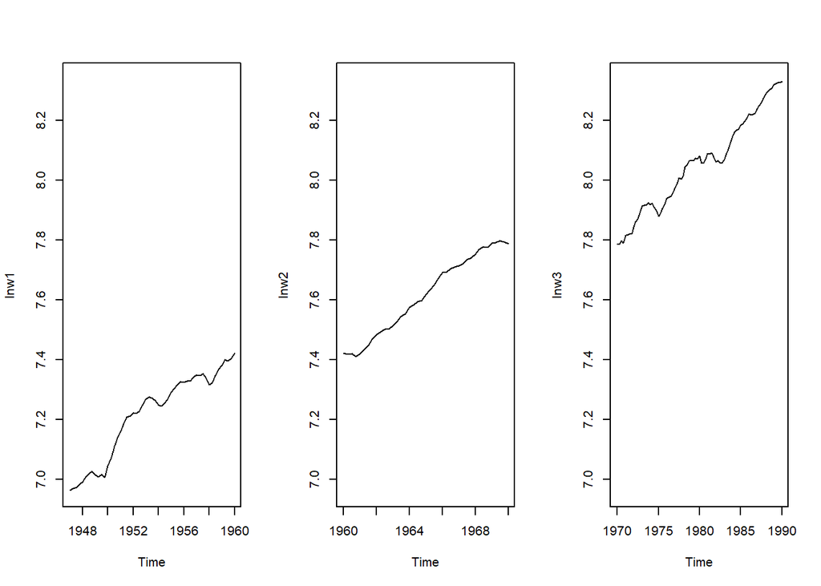

```r
lnw1 <- window(lngnpsh,start=1947,end=1960)
lnw2 <- window(lngnpsh,start=1960,end=1970)
lnw3 <- window(lngnpsh,start=1970,end=1990)

par(mfrow=c(1,3))
plot(lnw1,ylim=c(min(lngnpsh),max(lngnpsh)))
plot(lnw2,ylim=c(min(lngnpsh),max(lngnpsh)))
plot(lnw3,ylim=c(min(lngnpsh),max(lngnpsh)))
```

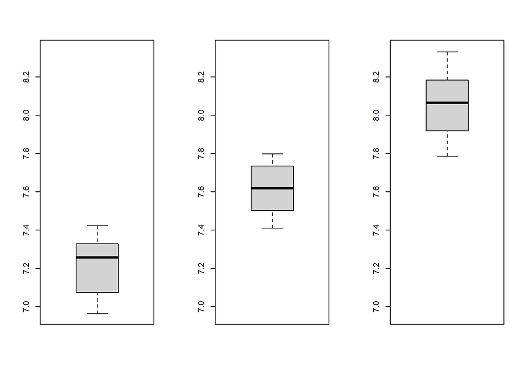

```r
par(mfrow=c(1,3))
boxplot(lnw1,ylim=c(min(lngnpsh),max(lngnpsh)))
boxplot(lnw2,ylim=c(min(lngnpsh),max(lngnpsh)))
boxplot(lnw3,ylim=c(min(lngnpsh),max(lngnpsh)))
```

#### Now the variance constant…

### Is seasonality present?

#### Nop, GNPSH series has been Seasonally adjusted

### Is the mean constant?

#### Cleary nop

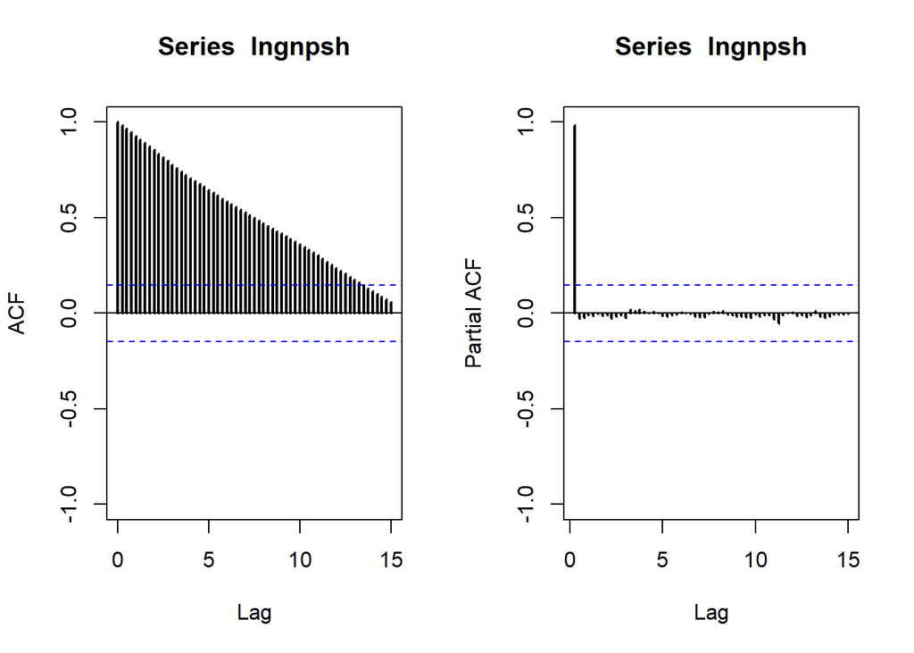

```r
par(mfrow=c(1,2))
acf(lngnpsh,ylim=c(-1,1),lag.max=60,lwd=2)
pacf(lngnpsh,ylim=c(-1,1),lag.max=60,lwd=2)
```

```r
par(mfrow=c(1,1))
```

#### Mean clearly non-constant because of a global linear trend => Non stationarity

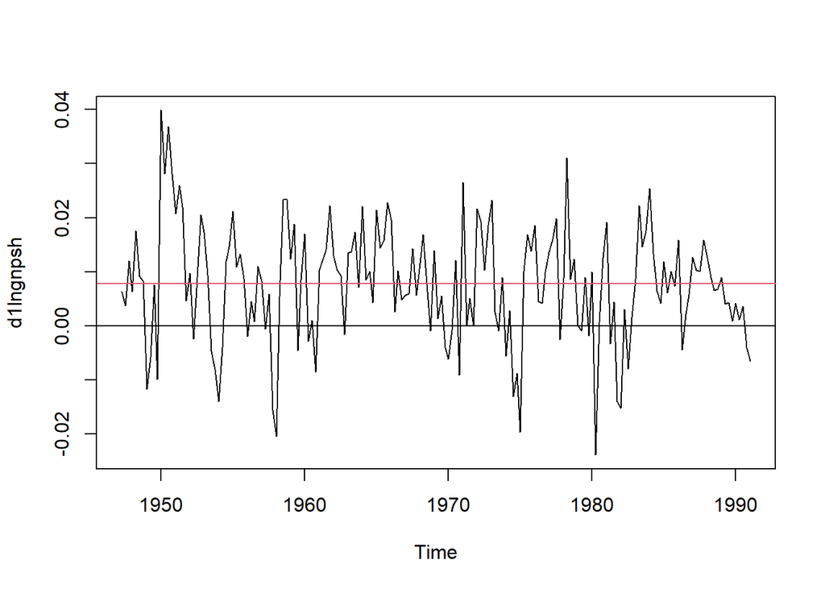

```r
# Regular difference to remove global linear trend
d1lngnpsh=diff(lngnpsh) #show difln equiv tasaincremrelativo ln(xt/xt-1)=(xt-xt-1)/xt-1
plot(d1lngnpsh)
abline(h=0)
abline(h=mean(d1lngnpsh), col = 2)
```

### Compare Variances: Overdifferencing?

```r
var(lngnpsh)
```

```
## [1] 0.1595917
```

```r
var(d1lngnpsh)
```

```
## [1] 0.0001150796
```

```r
var(diff(d1lngnpsh))
```

```
## [1] 0.0001430604
```

#### Extra regular difference not needed!

### Is the transformed series already stationary? Plot both, the ACF and PACF, and decide!!

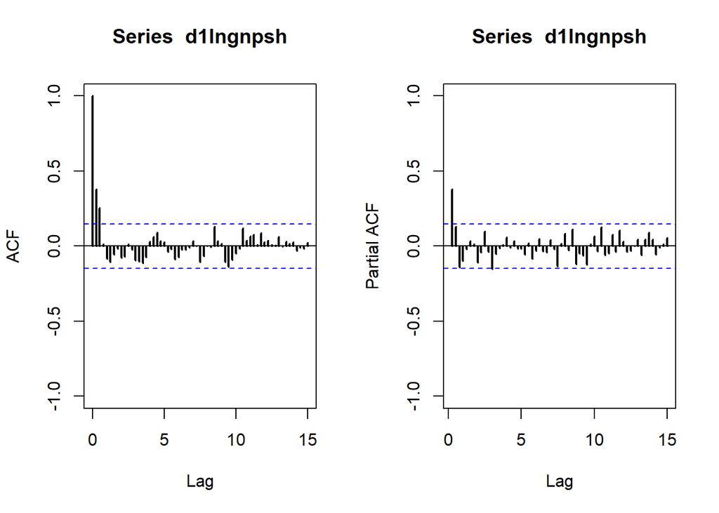

```r
# Now we have constant mean (different from zero!), constant variance and ACF with few significants lags => Stationarity
par(mfrow=c(1,2))
acf(d1lngnpsh,ylim=c(-1,1),lag.max=60,lwd=2)
pacf(d1lngnpsh,ylim=c(-1,1),lag.max=60,lwd=2)
```

```r
par(mfrow=c(1,1))
```

### Summary: Series d1lngnpsh has constant mean and variance.ACF decaying rapidly towards 0. => Stationarity achieved

$$W_t=(1-B)\log X_t=\log X_t-\log X_{t-1}$$

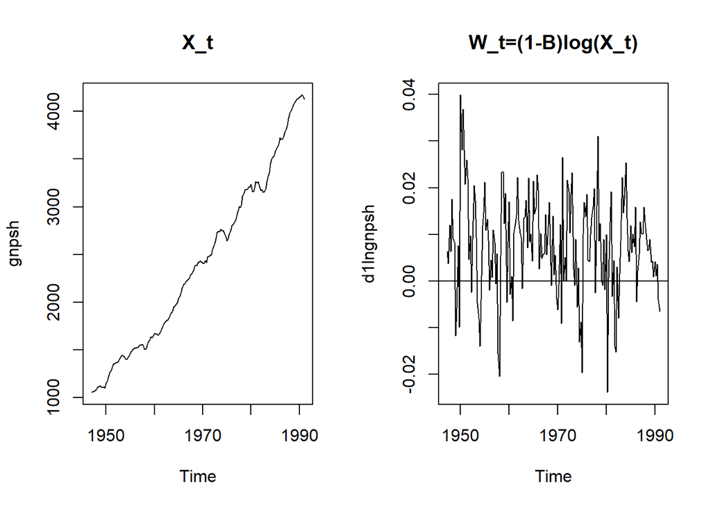

```r
par(mfrow=c(1,2))
plot(gnpsh,main="X_t")
plot(d1lngnpsh,main="W_t=(1-B)log(X_t)")
abline(h=0)
```

```r
par(mfrow=c(1,1))
```

### 3. AirPassengers

Monthly Airline Passenger Numbers 1949-1960

Description: The classic Box & Jenkins airline data. Monthly totals of international airline passengers, 1949 to 1960.

```r
AirPassengers
```

```
##      Jan Feb Mar Apr May Jun Jul Aug Sep Oct Nov Dec
## 1949 112 118 132 129 121 135 148 148 136 119 104 118
## 1950 115 126 141 135 125 149 170 170 158 133 114 140
## 1951 145 150 178 163 172 178 199 199 184 162 146 166
## 1952 171 180 193 181 183 218 230 242 209 191 172 194
## 1953 196 196 236 235 229 243 264 272 237 211 180 201
## 1954 204 188 235 227 234 264 302 293 259 229 203 229
## 1955 242 233 267 269 270 315 364 347 312 274 237 278
## 1956 284 277 317 313 318 374 413 405 355 306 271 306
## 1957 315 301 356 348 355 422 465 467 404 347 305 336
## 1958 340 318 362 348 363 435 491 505 404 359 310 337
## 1959 360 342 406 396 420 472 548 559 463 407 362 405
## 1960 417 391 419 461 472 535 622 606 508 461 390 432
```

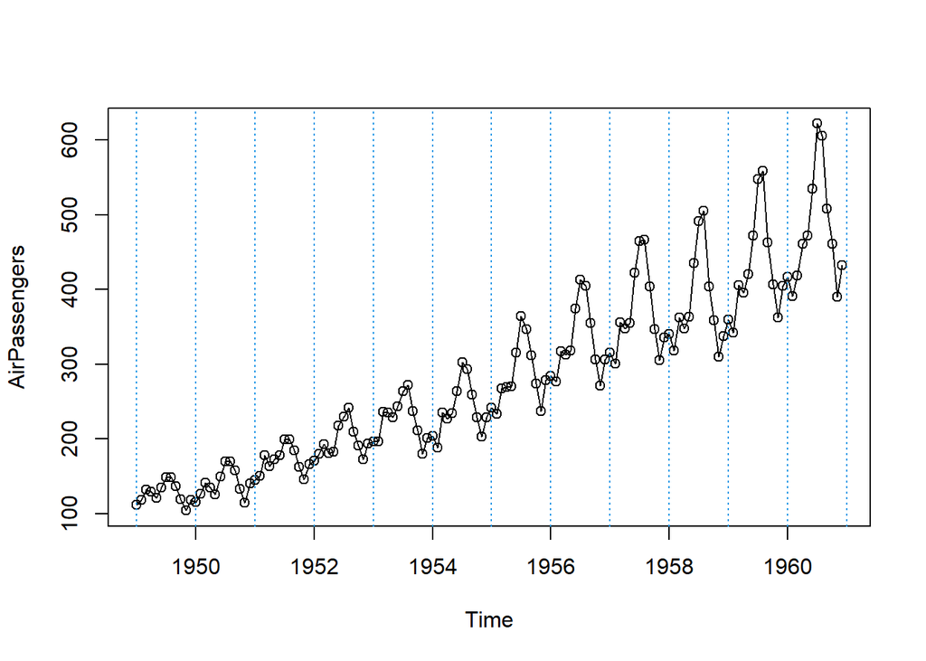

```r
plot(AirPassengers,type="o")
abline(v=1949:1961,col=4,lty=3)
```

```r
#LA:
(start(AirPassengers))
```

```
## [1] 1949    1
```

```r
(end(AirPassengers))
```

```
## [1] 1960   12
```

```r
(fq=frequency(AirPassengers))
```

```
## [1] 12
```

```r
length(AirPassengers)
```

```
## [1] 144
```

### Is Variance constant?

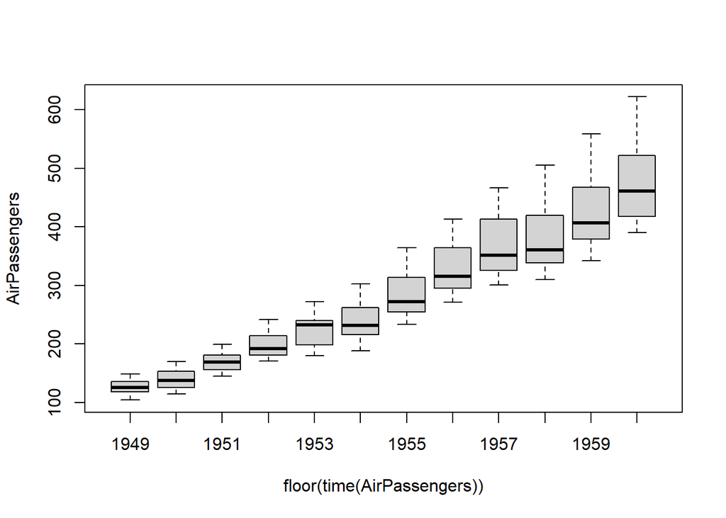

```r
boxplot(AirPassengers~floor(time(AirPassengers)))
```

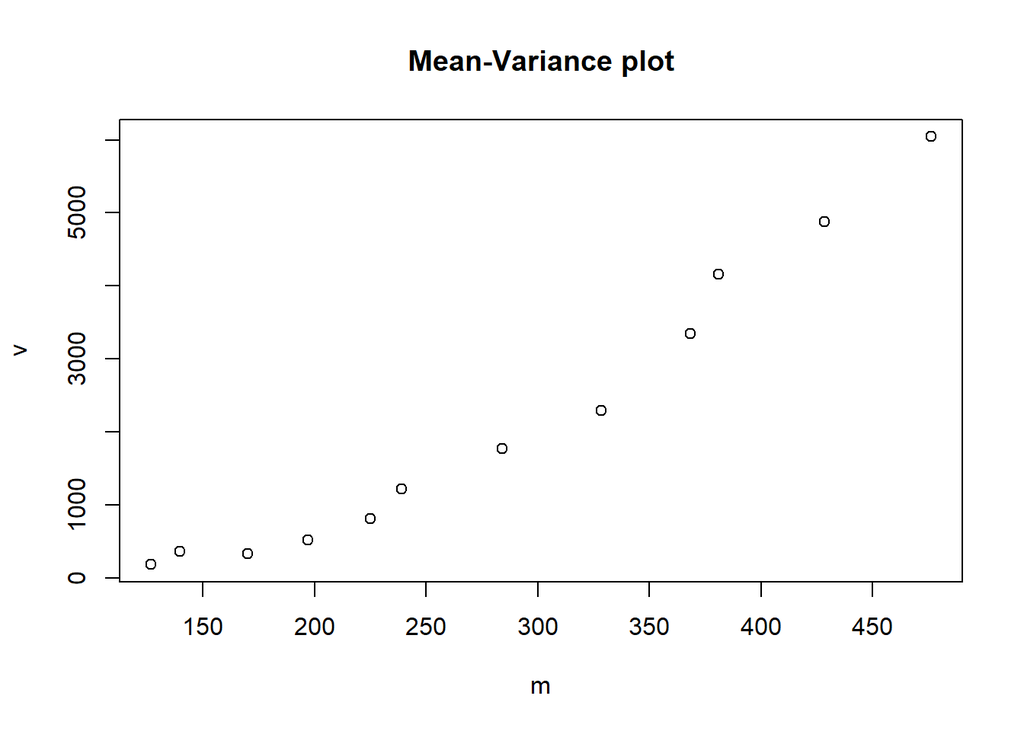

```r
m=apply(matrix(AirPassengers,ncol=12),2,mean)
v=apply(matrix(AirPassengers,ncol=12),2,var)
plot(v~m,main="Mean-Variance plot")
```

#### Variance is not constant: higher when the level raises => Non-Stationarity

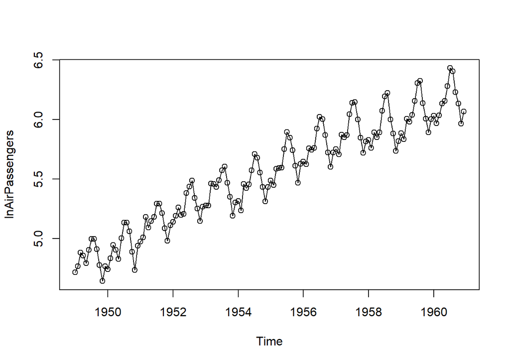

```r
# Logarithms of the data to stabilize the variance
lnAirPassengers=log(AirPassengers)
plot(lnAirPassengers,type="o")
```

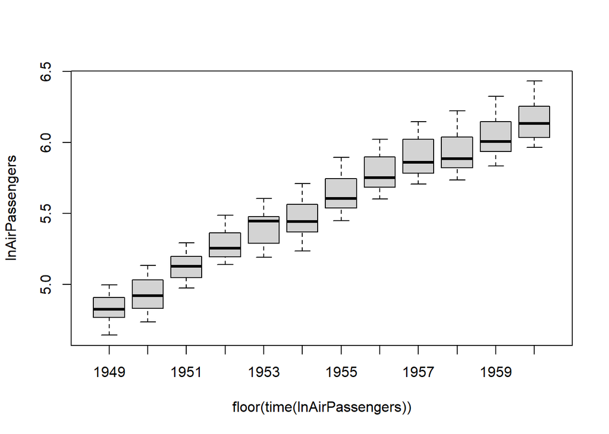

```r
boxplot(lnAirPassengers~floor(time(lnAirPassengers)))
```

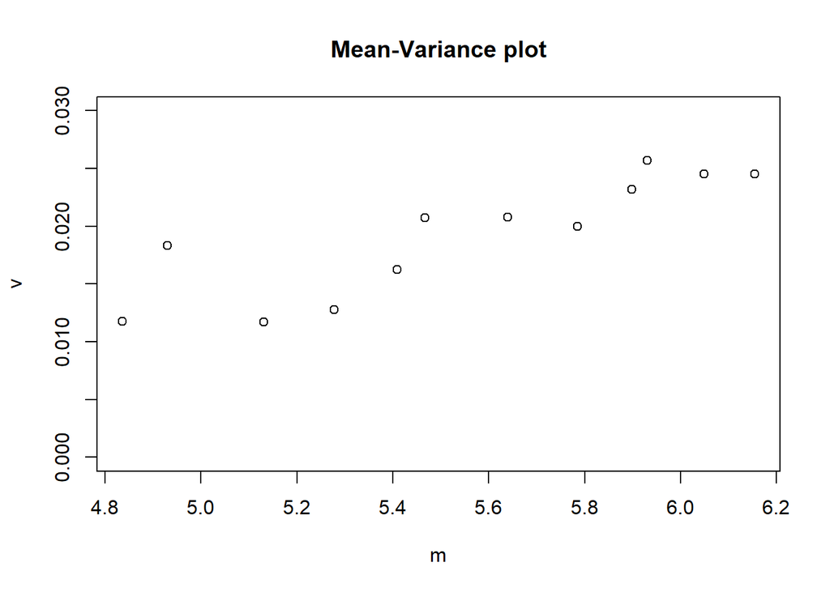

```r
m=apply(matrix(lnAirPassengers,ncol=12),2,mean)
v=apply(matrix(lnAirPassengers,ncol=12),2,var)
plot(v~m,main="Mean-Variance plot", ylim =c(0,0.03))
```

#### Now, the variance can be considered constant => Solved

### Is there seasonality present?

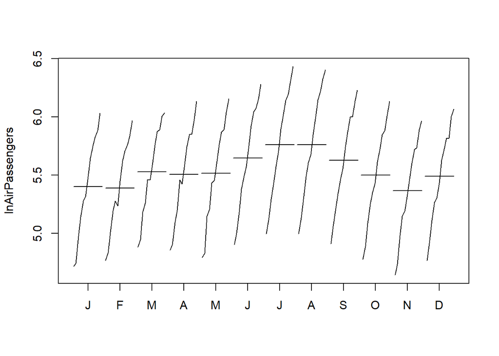

```r
# Similar pattern each year (12 observations) implies seasonality => Non-Sationarity
monthplot(lnAirPassengers)
```

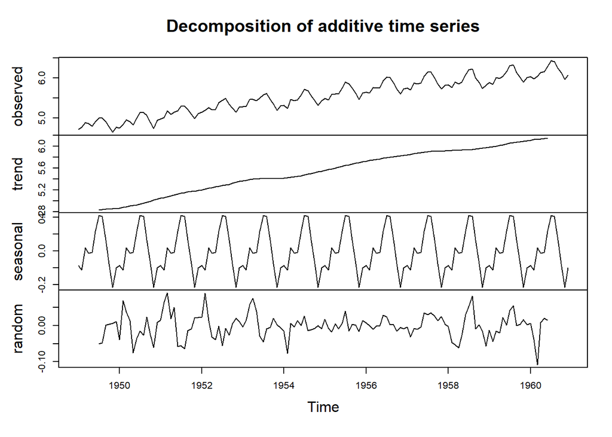

```r
plot(decompose(lnAirPassengers))
```

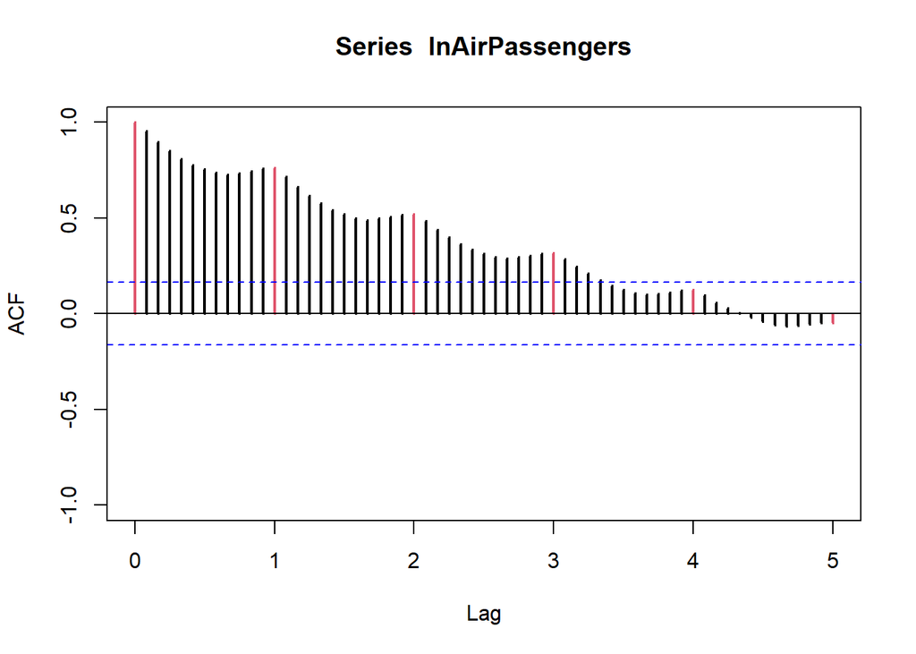

```r
# ACF decreasing slowly => non-stationarity
acf(lnAirPassengers,ylim=c(-1,1),lag.max=60,col=c(2,rep(1,11)),lwd=2)
```

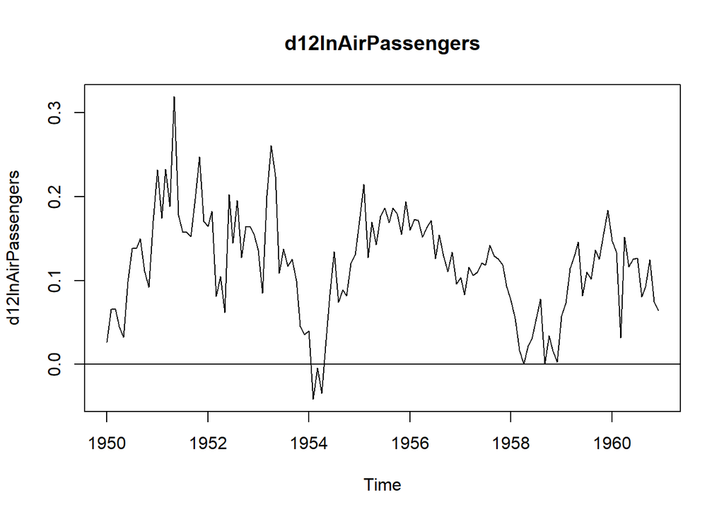

```r
# Difference of order 12 to remove the seasonal component
d12lnAirPassengers<-diff(lnAirPassengers,lag=12)
plot(d12lnAirPassengers,main="d12lnAirPassengers")
abline(h=0)
```

### Is the mean constant?

#### Not clear! Apply a regular fifference

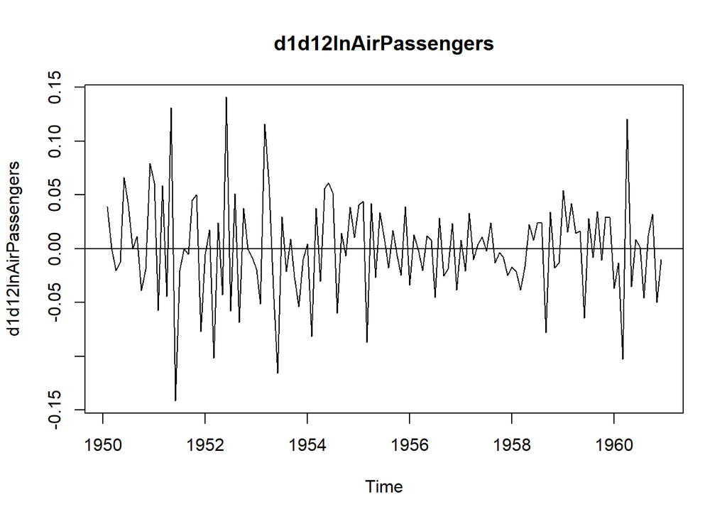

```r
# Constant mean? Not clear!
# Another Regular Difference to remove unit roots

d1d12lnAirPassengers<-diff(d12lnAirPassengers)
plot(d1d12lnAirPassengers,main="d1d12lnAirPassengers")
abline(h=0)
```

```r
# Let's check the variances to decide the number of differences
var(lnAirPassengers)
```

```
## [1] 0.1948838
```

```r
var(d12lnAirPassengers)
```

```
## [1] 0.003800061
```

```r
var(d1d12lnAirPassengers)
```

```
## [1] 0.002102066
```

```r
var(diff(d1d12lnAirPassengers))
```

```
## [1] 0.005669296
```

#### Extra regular difference not needed!

### Is the transformed series already stationary? Plot both, the ACF and PACF, and decide!!

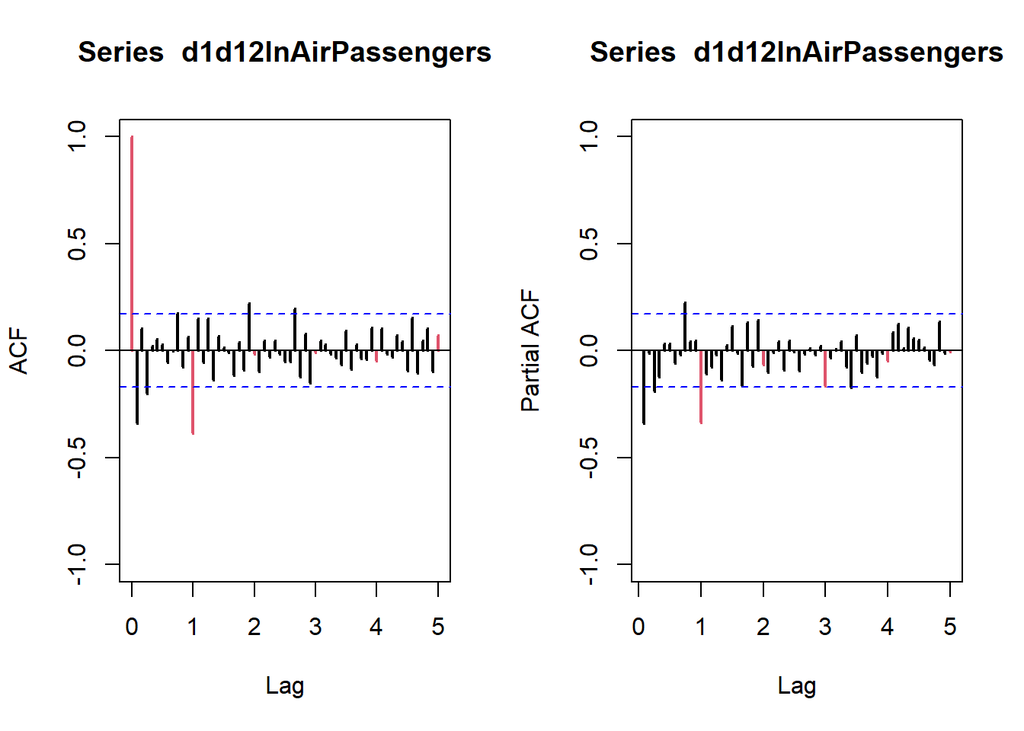

```r
# Constant mean, constant variance (!) and fast decay in the ACF =>Stationarity
par(mfrow=c(1,2))
acf(d1d12lnAirPassengers,ylim=c(-1,1),lag.max=60,col=c(2,rep(1,11)),lwd=2)
pacf(d1d12lnAirPassengers,ylim=c(-1,1),lag.max=60,col=c(rep(1,11),2),lwd=2)
```

```r
par(mfrow=c(1,1))
```

### Summary: Series d1d12lnAirPassengers has constant mean and variance.ACF decaying rapidly towards 0. => Stationarity achieved

$$W_t=(1-B)(1-B^{12})\log X_t$$

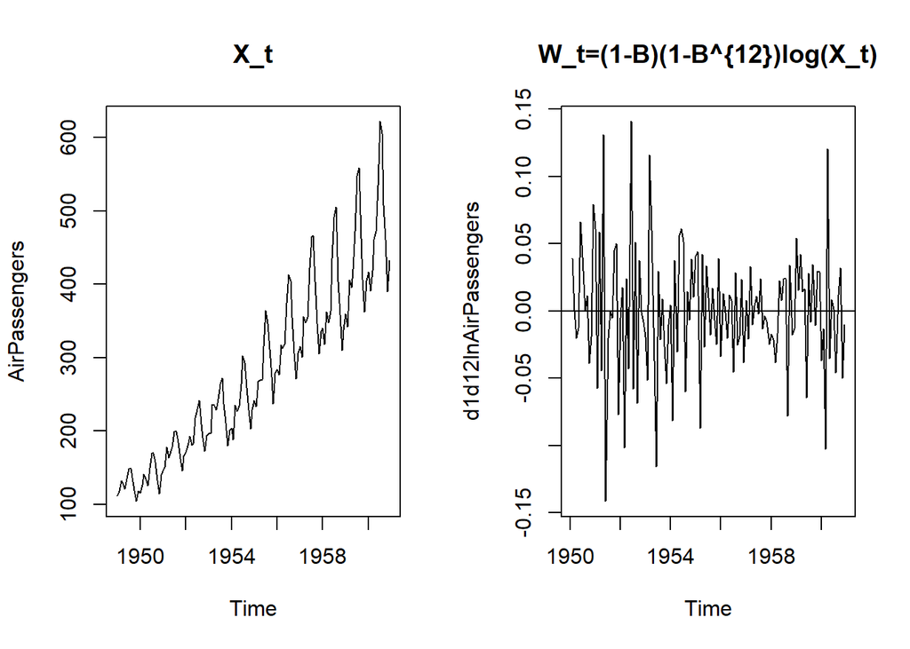

```r
par(mfrow=c(1,2))
plot(AirPassengers,main="X_t")
plot(d1d12lnAirPassengers,main="W_t=(1-B)(1-B^{12})log(X_t)")
abline(h=0)
```

```r
par(mfrow=c(1,1))
```

## Complementary Examples

### I) A White Noise Process?

### RANDOM Series

200 observations of White Noise with variance=1 (independent!)

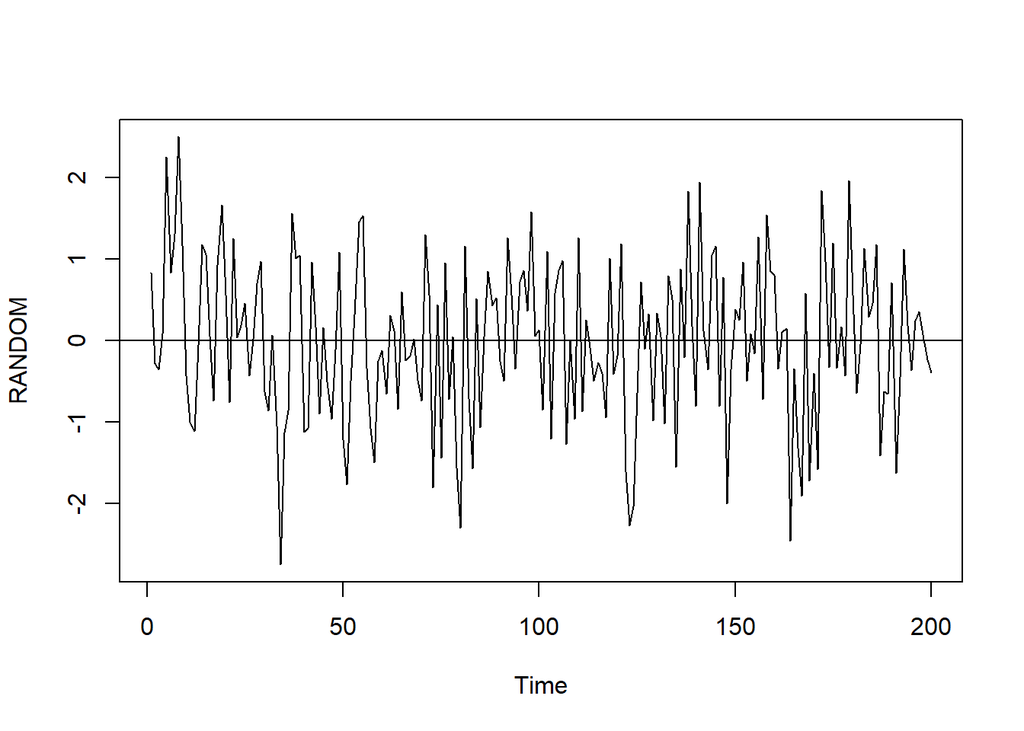

```r
# By fixing the seed of simulation, we can reproduce the pseudo-random sequence
set.seed(123456)
RANDOM=rnorm(200, mean=0, sd=1)
ts.plot(RANDOM)
abline(h=0)
```

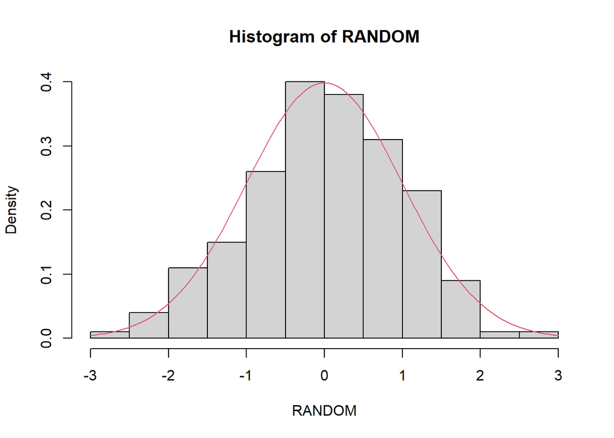

```r
# Constant mean and variance are clear

# Normal distribution verified:

# Histogram with theoretical distribution overlaped
hist(RANDOM,prob=T)
curve(dnorm,col=2,add=T)
```

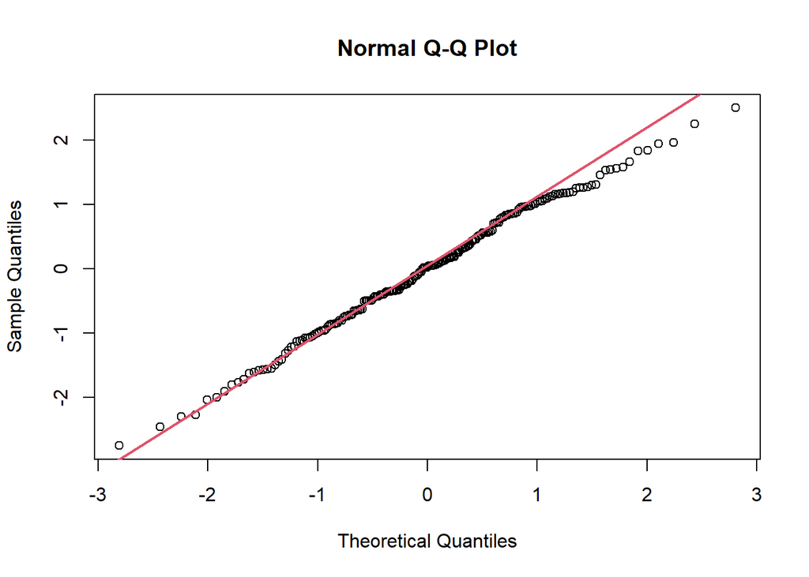

```r
# Normal-probability plot (quantile-qunatile)
qqnorm(RANDOM)
qqline(RANDOM,lwd=2,col=2)
```

```r
# Shapiro-Wilks Test for normality
shapiro.test(RANDOM)
```

```
##
##  Shapiro-Wilk normality test
##
## data:  RANDOM
## W = 0.99461, p-value = 0.6913
```

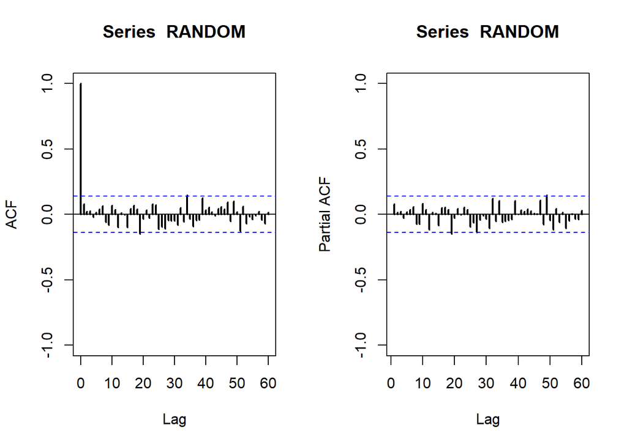

```r
# Independence verified:

# All lags in the ACF/PACF are non-significant
par(mfrow=c(1,2))
acf(RANDOM,ylim=c(-1,1),lag.max=60,lwd=2)
pacf(RANDOM,ylim=c(-1,1),lag.max=60,lwd=2)
```

```r
par(mfrow=c(1,1))

# Durbin-Watson test for autocorrelation
library(lmtest)
dwtest(RANDOM~1)
```

```
##
##  Durbin-Watson test
##
## data:  RANDOM ~ 1
## DW = 1.8367, p-value = 0.123
## alternative hypothesis: true autocorrelation is greater than 0
```

### II) Seasonal or Cyclic Behavior?

### SUNSPOT

Yearly Sunspot Data, 1700-1988

```r
sunspot.year
```

```
## Time Series:
## Start = 1700
## End = 1988
## Frequency = 1
##   [1]   5.0  11.0  16.0  23.0  36.0  58.0  29.0  20.0  10.0   8.0   3.0   0.0
##  [13]   0.0   2.0  11.0  27.0  47.0  63.0  60.0  39.0  28.0  26.0  22.0  11.0
##  [25]  21.0  40.0  78.0 122.0 103.0  73.0  47.0  35.0  11.0   5.0  16.0  34.0
##  [37]  70.0  81.0 111.0 101.0  73.0  40.0  20.0  16.0   5.0  11.0  22.0  40.0
##  [49]  60.0  80.9  83.4  47.7  47.8  30.7  12.2   9.6  10.2  32.4  47.6  54.0
##  [61]  62.9  85.9  61.2  45.1  36.4  20.9  11.4  37.8  69.8 106.1 100.8  81.6
##  [73]  66.5  34.8  30.6   7.0  19.8  92.5 154.4 125.9  84.8  68.1  38.5  22.8
##  [85]  10.2  24.1  82.9 132.0 130.9 118.1  89.9  66.6  60.0  46.9  41.0  21.3
##  [97]  16.0   6.4   4.1   6.8  14.5  34.0  45.0  43.1  47.5  42.2  28.1  10.1
## [109]   8.1   2.5   0.0   1.4   5.0  12.2  13.9  35.4  45.8  41.1  30.1  23.9
## [121]  15.6   6.6   4.0   1.8   8.5  16.6  36.3  49.6  64.2  67.0  70.9  47.8
## [133]  27.5   8.5  13.2  56.9 121.5 138.3 103.2  85.7  64.6  36.7  24.2  10.7
## [145]  15.0  40.1  61.5  98.5 124.7  96.3  66.6  64.5  54.1  39.0  20.6   6.7
## [157]   4.3  22.7  54.8  93.8  95.8  77.2  59.1  44.0  47.0  30.5  16.3   7.3
## [169]  37.6  74.0 139.0 111.2 101.6  66.2  44.7  17.0  11.3  12.4   3.4   6.0
## [181]  32.3  54.3  59.7  63.7  63.5  52.2  25.4  13.1   6.8   6.3   7.1  35.6
## [193]  73.0  85.1  78.0  64.0  41.8  26.2  26.7  12.1   9.5   2.7   5.0  24.4
## [205]  42.0  63.5  53.8  62.0  48.5  43.9  18.6   5.7   3.6   1.4   9.6  47.4
## [217]  57.1 103.9  80.6  63.6  37.6  26.1  14.2   5.8  16.7  44.3  63.9  69.0
## [229]  77.8  64.9  35.7  21.2  11.1   5.7   8.7  36.1  79.7 114.4 109.6  88.8
## [241]  67.8  47.5  30.6  16.3   9.6  33.2  92.6 151.6 136.3 134.7  83.9  69.4
## [253]  31.5  13.9   4.4  38.0 141.7 190.2 184.8 159.0 112.3  53.9  37.5  27.9
## [265]  10.2  15.1  47.0  93.8 105.9 105.5 104.5  66.6  68.9  38.0  34.5  15.5
## [277]  12.6  27.5  92.5 155.4 154.7 140.5 115.9  66.6  45.9  17.9  13.4  29.2
## [289] 100.2
```

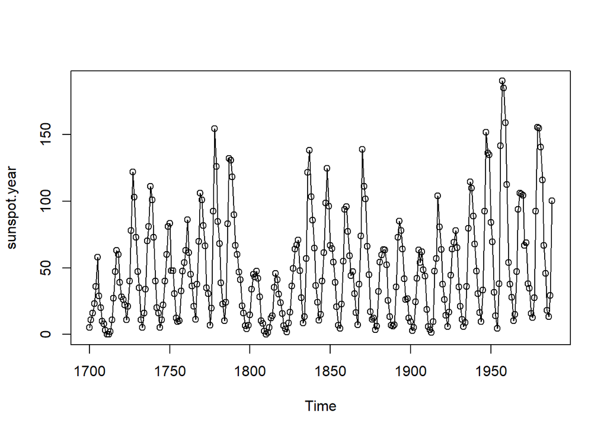

```r
plot(sunspot.year,type="o")
```

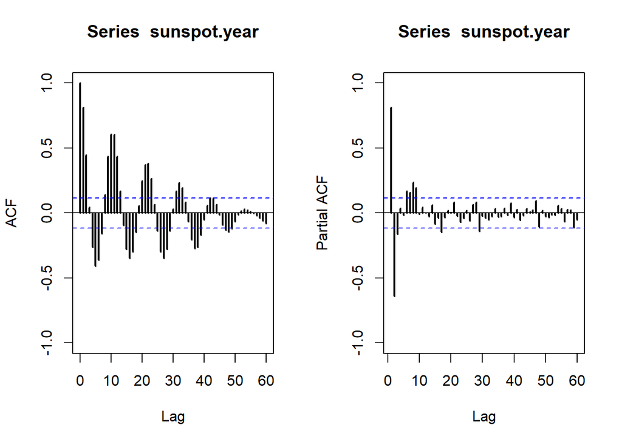

```r
# It seems a similar pattern repeating, but the frequency is not constant!
# It's not seasonality but cycles!!!
# Difference is not a solution. AR(p) with large p is!
par(mfrow=c(1,2))
acf(sunspot.year,ylim=c(-1,1),lag.max=60,lwd=2)
pacf(sunspot.year,ylim=c(-1,1),lag.max=60,lwd=2)
```

```r
par(mfrow=c(1,1))
```